# SGG Piper

André Soares

1 March 2018

Just so this looks like what I’m doing in the main script, including complete SGG data import and extracting metadata from the SGG phyloseq object.

```r
SGG_SVt = readRDS("/media/andre/B2F8C9A0F8C962E9/SGG_16S_analysis/SGG_16S_data_trimmed_DADA2_table/seqtab_final.rds")
SGG_Tax = readRDS("/media/andre/B2F8C9A0F8C962E9/SGG_16S_analysis/SGG_16S_data_trimmed_DADA2_table/tax_final.rds")
sgg_metadata<-read.csv("/media/andre/B2F8C9A0F8C962E9/SGG_16S_analysis/SGG_16S_metadata/SGG_metadata.csv", header=TRUE)
order<-rownames(SGG_SVt)
sgg_metadata_ord<-sgg_metadata[match(order, sgg_metadata$Sample_Code),]
rownames(sgg_metadata_ord) <- sgg_metadata_ord$Sample_Code
ps <- phyloseq(otu_table(SGG_SVt, taxa_are_rows=FALSE),
               sample_data(sgg_metadata_ord),
               tax_table(SGG_Tax))
ps.a = subset_samples(ps, Site.name != "Taffs Well PUMPED")
ps.b = subset_samples(ps.a, Sample_type != "Control")
ps.b <- prune_taxa(taxa_sums(ps.b) > 0, ps.b)
#order months
sample_data(ps.b)$Month = factor(sample_data(ps.b)$Month,
                                 levels = c("April","August","December"))
#to relative abundances
ps.b = subset_taxa(ps.b, Kingdom %in% c("Archaea", "Bacteria"))
ps.b.r <-  transform_sample_counts(ps.b, function(x) {x/sum(x)} )
sample_data(ps.b.r)$Site.name = factor(sample_data(ps.b.r)$Site.name,
                                          levels = c("Blaenavon","Cefn Hengoed","Mountain Gate","Taff Bargoed",
                                                     "Glyncastle","Dinas","Ynysarwed","Celynen North","Morlais",
                                                     "Lindsay","Six Bells","Crumlin Navigation","Taffs Well"))
```

#### 1 - Checking metadata table and subsetting it to include only Ca, Mg, Na, K, Cl, $SO_4$.

All are in $\mu g.mL^{-1}$ *i.e.* ppm.

```r
metadata<-sample_data(ps.b.r)

ppm <- as.data.frame(list(
            Ca   = metadata$Ca.µg.mL,
            Mg   = metadata$Mg.µg.ml,
            Na   = metadata$Na.µg.ml,
            K    = metadata$K.µg.ml,
            Cl   = metadata$Cl..µg.ml,
            SO4  = metadata$SO4..µg.ml))
#Quick look at the table in ug/mL.
head(ppm)
```

```
##     Ca    Mg   Na    K    Cl    SO4
## 1 36.5 14.10 45.8 10.5 15.43  58.37
## 2 36.0 13.80 45.8 10.5 15.35  58.18
## 3 36.5 14.21 47.2 10.4 15.57  58.64
## 4 75.0 22.66 16.0 10.6  9.78 135.15
## 5 82.5 22.12 15.8 11.4  9.84 134.20
## 6 79.0 22.31 16.0 11.8  9.87 132.95
```

A couple values are missing from Ca and Mg (not shown) so substituting those for the corresponding means of the two other values for that site in the corresponding month.

```r
meq <- ppm
#correct some 'stuff'
meq$Ca[is.na(meq$Ca)] <- 55.25
meq$Mg[is.na(meq$Mg)] <- 36.9
```

#### 2 - Converting to $meq.L^{-1}$:

```r
#division by atomic weight
meq$Ca = meq$Ca/40.078
meq$Mg = meq$Mg/24.305
meq$Na = meq$Na/22.989769
meq$K = meq$K/39.0983
meq$Cl = meq$Cl/35.453
meq$SO4 = meq$SO4/96.06

#multiplication by valence
meq$Ca = meq$Ca*2
meq$Mg = meq$Mg*2
meq$Na = meq$Na*1
meq$K = meq$K*1
meq$Cl = meq$Cl*1
meq$SO4 = meq$SO4*2

#miliequivalents per litre table.
head(meq)
```

```
##         Ca       Mg        Na         K        Cl      SO4
## 1 1.821448 1.160255 1.9921905 0.2685539 0.4352241 1.215282
## 2 1.796497 1.135569 1.9921905 0.2685539 0.4329676 1.211326
## 3 1.821448 1.169307 2.0530872 0.2659962 0.4391730 1.220904
## 4 3.742702 1.864637 0.6959618 0.2711115 0.2758582 2.813866
## 5 4.116972 1.820202 0.6872622 0.2915728 0.2775506 2.794087
## 6 3.942312 1.835836 0.6959618 0.3018034 0.2783968 2.768062
```

`HCO3` is created as a column by subtracting the total anions (Cl, $SO_4$) from the total cations (Ca, Mg, Na, K).

```r
meq_pc <- meq
totalCations <- meq_pc$Ca + meq_pc$Mg + meq_pc$Na + meq_pc$K
totalAnions <- meq_pc$Cl + meq_pc$SO4
#creating and HCO3 column
meq_pc$HCO3 <- (totalCations-totalAnions)
meq_pc$HCO3[meq_pc$HCO3<0] <- 0
#miliequivalents per litre table now with HCO3
head(meq_pc)
```

```
##         Ca       Mg        Na         K        Cl      SO4     HCO3
## 1 1.821448 1.160255 1.9921905 0.2685539 0.4352241 1.215282 3.591941
## 2 1.796497 1.135569 1.9921905 0.2685539 0.4329676 1.211326 3.548516
## 3 1.821448 1.169307 2.0530872 0.2659962 0.4391730 1.220904 3.649762
## 4 3.742702 1.864637 0.6959618 0.2711115 0.2758582 2.813866 3.484687
## 5 4.116972 1.820202 0.6872622 0.2915728 0.2775506 2.794087 3.844371
## 6 3.942312 1.835836 0.6959618 0.3018034 0.2783968 2.768062 3.729456
```

#### 3 - Normalising each column having in account total cation and anion sums (`totalCations`,`totalAnions`).

```r
meq_pc$Ca <- 100 * (meq_pc$Ca/totalCations)
meq_pc$Mg <- 100 * (meq_pc$Mg/totalCations)
meq_pc$Na <- 100 * (meq_pc$Na/totalCations)
meq_pc$K <- 100 * (meq_pc$K/totalCations)

#totalAnions_2 to include HCO3 as a cation in the sum.
totalAnions_2 <- meq_pc$Cl + meq_pc$SO4 + meq_pc$HCO3
meq_pc$Cl <- 100 * (meq_pc$Cl/totalAnions_2)
meq_pc$SO4 <- 100 * (meq_pc$SO4/totalAnions_2)
meq_pc$HCO3 <- 100 * (meq_pc$HCO3/totalAnions_2)

#do all cation and anion rows sum to 100?
#Cations
100 %in% apply(meq_pc[, c("Ca", "Mg", "Na", "K")], 1, FUN = sum)
```

```
## [1] TRUE
```

```r
#Anions
100 %in% apply(meq_pc[, c("Cl", "SO4", "HCO3")], 1, FUN = sum)
```

```
## [1] TRUE
```

```r
#Cool

#final normalized miliequivalents per litre table with HCO3
head(meq_pc)
```

```
##         Ca       Mg        Na        K       Cl      SO4     HCO3
## 1 34.74423 22.13193 38.001152 5.122681 8.301925 23.18158 68.51650
## 2 34.59585 21.86810 38.364402 5.171648 8.337828 23.32699 68.33518
## 3 34.30327 22.02151 38.665719 5.009498 8.270930 22.99324 68.73584
## 4 56.92831 28.36203 10.585916 4.123738 4.195937 42.80027 53.00379
## 5 59.52815 26.31867  9.937267 4.215911 4.013161 40.40028 55.58656
## 6 58.18127 27.09356 10.271113 4.454062 4.108623 40.85149 55.03989
```

#### 4 - Transforming data to x, y coordinates

```r
data <- as.data.frame(meq_pc)
colnames(data) <- c("Ca","Mg","Na","K","Cl","SO4", "HCO3")
data$Site_name <- metadata$Site.name

piper_data <- transform_piper_data(Ca   = data$Ca,
                                   Mg   = data$Mg,
                                   Cl   = data$Cl,
                                   SO4  = data$SO4,
                                   name = data$Site_name)
```

#### 5 - Plotting the Piper diagram.

Still have to find a way to define shape by Month.

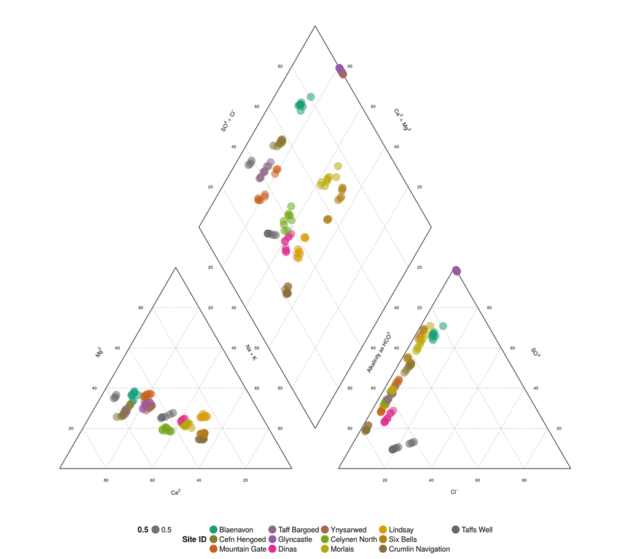

```r
piper_cols = colorRampPalette(brewer.pal(8, "Dark2"))(13)
piper_cols_c = gsub("#DD2456", "#9c183c", piper_cols)
piper_cols_c = gsub("#A0BAAC", "#749a85", piper_cols_c)
piper_cols_c = gsub("#E4B9A3", "#489fca", piper_cols_c)
piper_cols_c = gsub("#FEEB93", "#f58e03", piper_cols_c)
piper_cols_c = gsub("#FDC988", "#c988fd", piper_cols_c)
piper_cols_c = gsub("#D1DD9E", "#b6c965", piper_cols_c)
piper_cols_c = gsub("#FDC086", "#fc993b", piper_cols_c)

sgg_piper <- ggplot_piper() + geom_point(data=piper_data,
                            aes(x,y,
                                colour=factor(observation),
                            alpha = 0.5),
                            size = 7)+
  scale_color_manual(name = "Site ID",
                     values = piper_cols_c) +
  theme(legend.position = "bottom",
        legend.text = element_text(size = 15),
        legend.title = element_text(size = 16,
                                    face = "bold")) +
  guides(colour = guide_legend(nrow = 3),
         size = guide_legend(override.aes = element_blank()),
         alpha = guide_legend(override.aes = element_blank()))

  sgg_piper
```

Contrast that to this Piper diagram showing the distribution of the four main groundwater types in the South Wales Coal Measures Group (after Ineson, 1967).

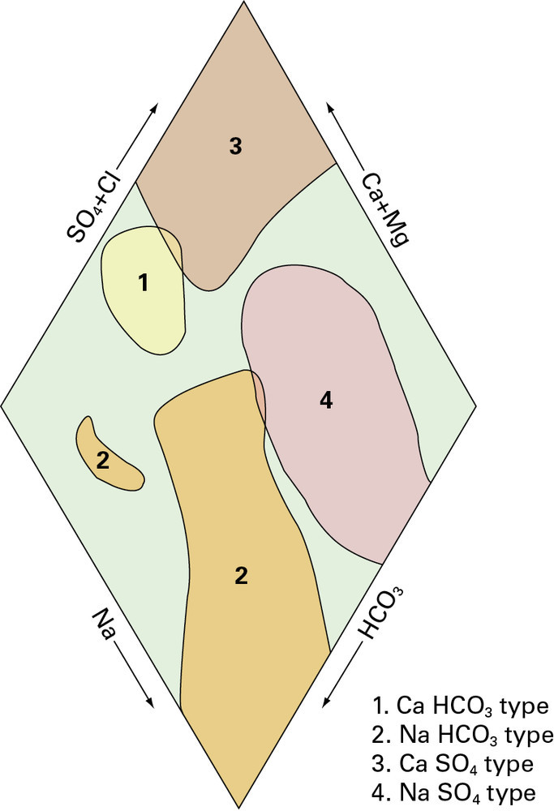

```r
bgs_piper = "/media/andre/B2F8C9A0F8C962E9/SGG_16S_analysis/SGG_16S_R/P859276.jpg"
include_graphics(bgs_piper)
```